# Task 1

Demographic parity: P(Y' = 1 | A = Blue) / P(Y' = 1 | A = Red) = (65/100) / (1/2) = 130 / 100 = 1.3

Equal opportunity: P(Y' = 1 | A = Blue, Y = 1) / P(Y' = 1 | A = Red, Y = 1) = (60/80) / (1/2) = 120 / 80 = 1.5

Predictive rate parity: P(Y = 1 | A = Blue, Y' = 1) / P(Y = 1 | A = Red, Y' = 1) = (60/65) / (1/2) = 120 / 65 = 24 / 13 ~ 1.85

# Task 2

## Evaluating fairness coefficients for models trained to predict credit granting with age as a protected attribute

We consider a problem of predicting credit granting with age as a protected attribute. We train a linear model, log-linear model and a random forest model on full data and a linear model on the data with substracted the protected attribute.

We evaluate three fairness coefficients: Statistical parity, Equal opportunity and Predictive parity. We also apply ROC pivot method to mitigate the data bias. We compare changes in fairness metrics and fitting metrics (MSE and MAE) and analyze results.

### Linear model fairness coefficients

We observe Statistical parity equal to 0.14, Equal opportunity equal to 0.56 and Predictive parity equal to 1.60.

Error of the model is equal to 0.07 both for MSE and MAE metric. The model seems to be not-perfectly fitted (predictions are in the [0, 1] interval, so 0.07 MAE and MSE are rather high) and strongly violates fairness conditions (espacially the value 0.14 is disturbing).

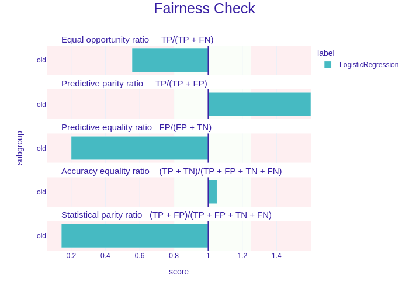

### Log-linear model fairness coefficients

We observe Statistical parity equal to 0.32, Equal opportunity equal to 0.61 and Predictive parity equal to 1.01.

Error of the model is equal to 0.93 both for MSE and MAE metric. The model seems to have more fair outputs (in terms of fairness coefficients), but is terribly fitted - MSE and MAE equal to 0.93 are huge. It is possible that the model swaps classes and if we applied prediction 1-model_output would get much better results.

[figure not shown]

### Random forest model fairness coefficients

We observe Statistical parity equal to 0.36, Equal opportunity equal to 0.76 and Predictive parity equal to 1.09.

Error of the model is equal to 0.06 for MSE and 0.11 for MAE metric. The model seems be fitted on very similar level as the linear model, but achieves much better fairness scores in all three metrices (even though not all of them satisfy the 4/5 rule).

[figure not shown]

### Linear model applied ROC pivot technique fairness coefficients

We observe Statistical parity equal to 0.80, Equal opportunity equal to 1.91 and Predictive parity equal to 1.33.

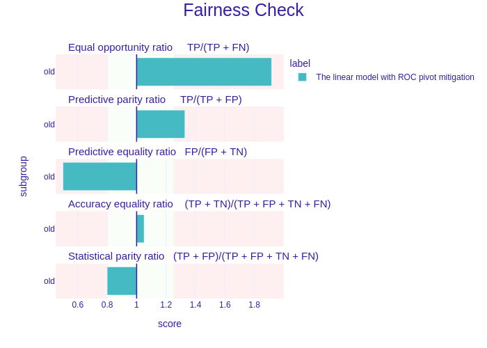

### Summary

We analyzed the three fairness coefficients (Statistical parity, Equal opportunity and Predictive parit) for different models (linear, log-linear, random forest).

We observed that linear model performed very poor in terms of the fairness coefficients. The log-linear model achieved better fairness coefficients, but was terribly fitted. The random forest model achieved the best result in terms of the fairness coefficients and similar to the linear model in terms of the fit.

We can conclude that the random forest model is the most reliable in this setup. Although it is worth mentioning that none of the models satisfied the 4/5 rule.

# Appendix

## Analysys of the model

```python
# 1. Import libraries

!pip3 install shap
!pip3 install dalex
!pip3 install lime
!pip3 install -q condacolab
import condacolab
condacolab.install()
!conda install -c conda-forge python-kaleido

import pandas as pd
import numpy as np
import matplotlib.pyplot as plt
import plotly
import kaleido

import pickle
import lime
import shap
import dalex as dx
import xgboost

from math import isclose

from sklearn.linear_model import LinearRegression, LogisticRegression
from sklearn.metrics import mean_absolute_error, mean_squared_error
from sklearn.ensemble import RandomForestClassifier
from sklearn.model_selection import train_test_split
```

[output not shown]

```python
# 2. Load the dataset

df = pd.read_csv('./cs-training.csv').drop(columns = ['Unnamed: 0']).dropna()
df['is_old'] = 1.0 * (df['age'] > 50)
df = df.drop(columns = ['age'])
df.head(15)
```

|  | SeriousDlqin2yrs | RevolvingUtilizationOfUnsecuredLines | NumberOfTime30-59DaysPastDueNotWorse | DebtRatio | MonthlyIncome | NumberOfOpenCreditLinesAndLoans | NumberOfTimes90DaysLate | NumberRealEstateLoansOrLines | NumberOfTime60-89DaysPastDueNotWorse | NumberOfDependents | is_old |
| --- | --- | --- | --- | --- | --- | --- | --- | --- | --- | --- | --- |
| 0 | 1 | 0.766127 | 2 | 0.802982 | 9120.0 | 13 | 0 | 6 | 0 | 2.0 | 0.0 |
| 1 | 0 | 0.957151 | 0 | 0.121876 | 2600.0 | 4 | 0 | 0 | 0 | 1.0 | 0.0 |
| 2 | 0 | 0.658180 | 1 | 0.085113 | 3042.0 | 2 | 1 | 0 | 0 | 0.0 | 0.0 |
| 3 | 0 | 0.233810 | 0 | 0.036050 | 3300.0 | 5 | 0 | 0 | 0 | 0.0 | 0.0 |
| 4 | 0 | 0.907239 | 1 | 0.024926 | 63588.0 | 7 | 0 | 1 | 0 | 0.0 | 0.0 |
| 5 | 0 | 0.213179 | 0 | 0.375607 | 3500.0 | 3 | 0 | 1 | 0 | 1.0 | 1.0 |
| 7 | 0 | 0.754464 | 0 | 0.209940 | 3500.0 | 8 | 0 | 0 | 0 | 0.0 | 0.0 |
| 9 | 0 | 0.189169 | 0 | 0.606291 | 23684.0 | 9 | 0 | 4 | 0 | 2.0 | 1.0 |
| 10 | 0 | 0.644226 | 0 | 0.309476 | 2500.0 | 5 | 0 | 0 | 0 | 0.0 | 0.0 |
| 11 | 0 | 0.018798 | 0 | 0.531529 | 6501.0 | 7 | 0 | 2 | 0 | 2.0 | 1.0 |
| 12 | 0 | 0.010352 | 0 | 0.298354 | 12454.0 | 13 | 0 | 2 | 0 | 2.0 | 0.0 |
| 13 | 1 | 0.964673 | 3 | 0.382965 | 13700.0 | 9 | 3 | 1 | 1 | 2.0 | 0.0 |
| 14 | 0 | 0.019657 | 0 | 477.000000 | 0.0 | 6 | 0 | 1 | 0 | 0.0 | 1.0 |
| 15 | 0 | 0.548458 | 0 | 0.209892 | 11362.0 | 7 | 0 | 1 | 0 | 2.0 | 1.0 |
| 17 | 0 | 0.166284 | 0 | 0.188274 | 8800.0 | 7 | 0 | 0 | 0 | 0.0 | 1.0 |

```python
print(len(df))

print("\n", df.dtypes)
```

```
120269

 SeriousDlqin2yrs                          int64
RevolvingUtilizationOfUnsecuredLines    float64
NumberOfTime30-59DaysPastDueNotWorse      int64
DebtRatio                               float64
MonthlyIncome                           float64
NumberOfOpenCreditLinesAndLoans           int64
NumberOfTimes90DaysLate                   int64
NumberRealEstateLoansOrLines              int64
NumberOfTime60-89DaysPastDueNotWorse      int64
NumberOfDependents                      float64
is_old                                  float64
dtype: object
```

```python
from sklearn.utils.multiclass import type_of_target
target = "SeriousDlqin2yrs"
features = df.drop(columns = [target]).columns

x = df[features]
y = df[target]


x_train, x_test, y_train, y_test = train_test_split(
    x, y, test_size=0.2, random_state=42
)
```

```python
# 3. Train a linear model (Point 1, 3)

model = LogisticRegression()
model.fit(x_train, y_train)

y_pred_test = model.predict(x_test)

mse_test = mean_squared_error(y_test, y_pred_test)
print("Training MSE: ", round(mse_test, 2))

mae_test = mean_absolute_error(y_test, y_pred_test)
print("Training MAE: ", round(mae_test, 2))
```

```
Training MSE:  0.07
Training MAE:  0.07
```

```python
# 4. Calculate fairness coefficients (Point 2, 3)

explainer = dx.Explainer(model, x_test, y_test, verbose = False)

protected_variable =  x_test.is_old.apply(lambda x: "old" if x == 1.0 else "young")

fobject = explainer.model_fairness(
    protected=protected_variable,
    privileged="young"
)

fobject.fairness_check()

print(fobject.result[['STP', 'TPR', 'PPV']].iloc[0])

fig = fobject.plot(show = False)

fig.write_image('Point2_im_1.png')
```

```
Bias detected in 4 metrics: TPR, PPV, FPR, STP

Conclusion: your model is not fair because 2 or more criteria exceeded acceptable limits set by epsilon.

Ratios of metrics, based on 'young'. Parameter 'epsilon' was set to 0.8 and therefore metrics should be within (0.8, 1.25)
          TPR       ACC  PPV  FPR       STP
old  0.555556  1.051934  1.6  0.2  0.142857
STP    0.142857
TPR    0.555556
PPV    1.600000
Name: old, dtype: float64
```

```python
# 5. Train a log-linear model and calculate fairness coefficients (Point 3, 5)

epsilon = 1e-6

log_x_train = np.log(np.abs(x_train) + epsilon)
log_x_test = np.log(np.abs(x_test) + epsilon)

log_model = LogisticRegression()
log_model.fit(log_x_train, y_train)
```

```
LogisticRegression()
```

```python
y_pred_test = log_model.predict(x_test)

mse_test = mean_squared_error(y_test, y_pred_test)
print("Test MSE: ", round(mse_test, 2))

mae_test = mean_absolute_error(y_test, y_pred_test)
print("Test MAE: ", round(mae_test, 2))

log_explainer = dx.Explainer(log_model, log_x_test, y_test, verbose = False)

protected_variable =  x_test.is_old.apply(lambda x: "old" if x == 1.0 else "young")

fobject = log_explainer.model_fairness(
    protected=protected_variable,
    privileged="young"
)

fobject.fairness_check()

print(fobject.result[['STP', 'TPR', 'PPV']].iloc[0])

fobject.plot(show = False)

fig.write_image('Point3_im_1.png')
```

```
Test MSE:  0.93
Test MAE:  0.93
Bias detected in 3 metrics: TPR, FPR, STP

Conclusion: your model is not fair because 2 or more criteria exceeded acceptable limits set by epsilon.

Ratios of metrics, based on 'young'. Parameter 'epsilon' was set to 0.8 and therefore metrics should be within (0.8, 1.25)
          TPR       ACC       PPV     FPR       STP
old  0.619318  1.047305  1.014981  0.3125  0.322581
STP    0.322581
TPR    0.619318
PPV    1.014981
Name: old, dtype: float64
```

```python
# 6. Train a random forest classifier (Point 3, 5)

forest_cls = RandomForestClassifier(n_estimators=40)
forest_cls.fit(x_train, y_train)
```

```
RandomForestClassifier(n_estimators=40)
```

```python
explainer_forest = dx.Explainer(forest_cls, x_test, y_test, verbose = False)

y_pred_test = explainer_forest.predict(x_test)

mse_test = mean_squared_error(y_test, y_pred_test)
print("Test MSE: ", round(mse_test, 2))

mae_test = mean_absolute_error(y_test, y_pred_test)
print("Test MAE: ", round(mae_test, 2))

protected_variable =  x_test.is_old.apply(lambda x: "old" if x == 1.0 else "young")

fobject = explainer_forest.model_fairness(
    protected=protected_variable,
    privileged="young"
)

fobject.fairness_check()

print(fobject.result[['STP', 'TPR', 'PPV']].iloc[0])

fig = fobject.plot(show = False)

fig.write_image('Point3_im_2.png')
```

```
Test MSE:  0.06
Test MAE:  0.11
Bias detected in 3 metrics: TPR, FPR, STP

Conclusion: your model is not fair because 2 or more criteria exceeded acceptable limits set by epsilon.

Ratios of metrics, based on 'young'. Parameter 'epsilon' was set to 0.8 and therefore metrics should be within (0.8, 1.25)
          TPR       ACC       PPV       FPR       STP
old  0.763285  1.051876  1.092929  0.318182  0.358974
STP    0.358974
TPR    0.763285
PPV    1.092929
Name: old, dtype: float64
```

```python
# 7. Perform a bias mitigation technique for the linear model (Point 4)

from dalex.fairness import resample, reweight, roc_pivot
from copy import copy

x_train_without_prot, x_test_without_prot = x_train.drop(columns = ["is_old"]), x_test.drop(columns = ["is_old"])

model_without_prot = LogisticRegression()
model_without_prot.fit(x_train_without_prot, y_train)

explainer_without_prot = dx.Explainer(
    model_without_prot,
    x_test_without_prot,
    y_test,
    label="Linear model without the protected attribute",
    verbose=False
)
```

[output not shown]

```python
protected_variable_train = x_train.is_old.apply(lambda x: "old" if x == 1.0 else "young")

# roc_pivot
explainer_roc_pivot = roc_pivot(
    copy(explainer_without_prot),
    protected_variable,
    "young",
    verbose=False
)
explainer_roc_pivot.label = 'The linear model with ROC pivot mitigation'
fobject_roc_pivot = explainer_roc_pivot.model_fairness(
    protected_variable,
    "young"
)

fobject_roc_pivot.fairness_check()

print(fobject_roc_pivot.result[['STP', 'TPR', 'PPV']].iloc[0])

fig = fobject_roc_pivot.plot(show = False)

fig.write_image('Point4_im_1.png')
```

```
Bias detected in 3 metrics: TPR, PPV, FPR

Conclusion: your model is not fair because 2 or more criteria exceeded acceptable limits set by epsilon.

Ratios of metrics, based on 'young'. Parameter 'epsilon' was set to 0.8 and therefore metrics should be within (0.8, 1.25)
          TPR       ACC       PPV  FPR  STP
old  1.916667  1.050773  1.327711  0.5  0.8
STP    0.800000
TPR    1.916667
PPV    1.327711
Name: old, dtype: float64
```